# Reproducible Research Using R

Jenna Krall  
October 31, 2014

[figure not shown]

### About me

- PhD in Biostatistics from Johns Hopkins
- Hopkins Biostat student computing club
  - Emphasis on new tools for using R
- “Implementing Reproducible Research'' (Stodden, Leisch, and Peng)

### Why am I interested in reproducible research?

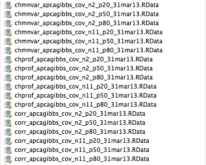

### Why am I interested in reproducible research?

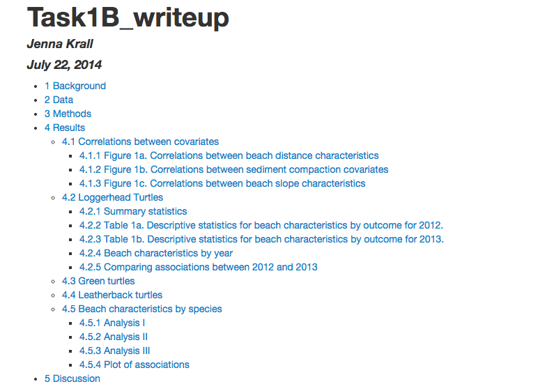

### What is reproducible research?

“…the calculation of quantitative scientific results by independent scientists using the original datasets and methods''

Which means:

- Replicability vs. Reproducibility
- reproducibility = tools + workflow''(Stodden, Leisch, and Peng)
- Literate statistical programming (Rossini via Knuth)
  - Programming language + documentation language
- **Linking data, code, results, and interpretation**
- Open science?

### Example 1: how did we make this plot?

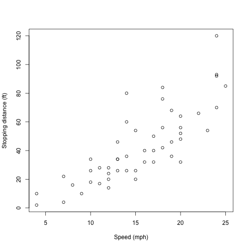

### Example 2: how did we compute those statistics?

What dataset are they from? If I don't know R, how can I make this table?

```
     speed           dist
 Min.   : 4.0   Min.   :  2
 1st Qu.:12.0   1st Qu.: 26
 Median :15.0   Median : 36
 Mean   :15.4   Mean   : 43
 3rd Qu.:19.0   3rd Qu.: 56
 Max.   :25.0   Max.   :120
```

### Example 3: Writing interpretations.

The R dataset *cars* has 2 variables which have the labels speed and dist. The dataset has 50 observations. The average speed reported was 15.4 miles per hour with a standard deviation (sd) of 5.2876. The average stopping distance was 42.98 (sd = 25.7694) feet.

### Introduction to knitr

knitr

- was developed by Yihui Xie at Iowa State (now at RStudio)
- has great integration with RStudio
- can be easily incorporated into your existing workflow
- is flexible and can be used with other programming languages (e.g. python) and documentation languages (e.g. html, LaTeX)

We will focus on using knitr to integrate R and markdown

### knitr using R + markdown

- knitr = parser + evaluator + renderer
- Text (in markdown) separated by code chunks (written in R)
- Can also incorporate in-line R
- Flexible output (pdf, html, word)